# Top 10 Matches

liza mladentseva

2025-03-19

## Introduction

This project explores a professional tennis match dataset sourced from [Kaggle - ATP Matches](https://www.kaggle.com/datasets/vladimirmijatovic/tennis-top-10-male-players-of-all-time/data?select=top_10_matches.csv). The dataset contains detailed information about tennis matches, including match results, player names, surfaces, rankings, and match statistics.

My goal is to investigate Federer’s and Nadal’s performance over time, their results on different surfaces, and match patterns against their top rivals. I will explore this using data wrangling, visualizations, and statistical analysis in R.

### Dataset Overview

- **Rows (matches):** The dataset contains over 9,000 match records.
- **Players:** It includes professional ATP players, with both winners and losers recorded.
- **Time span:** The matches span from 1978 to 2024.
- **Key variables include:**
  - `winner_name`, `loser_name`: Players involved
  - `surface`: Surface type (Clay, Grass, Hard)
  - `tourney_level`: Type of tournament (Grand Slam, Masters, etc.)
  - `winner_rank`, `loser_rank`: ATP rankings of players
  - `w_ace`, `l_ace`: Number of aces served by each player
  - `minutes`: Duration of the match

This dataset is suitable for performance analysis, trends, and comparisons.

## Variable Classification

- **Binary:** Win (logical values, typically representing True/False)
- **Nominal:** PlayerName (categories of names), GameType (categories without order), Country (names of countries)
- **Ordinal:** Rank (ranking in a game, has a meaningful order)
- **Discrete:** MatchID (countable, unique identifiers for each match), Score (countable points in a game), Age (countable, number of years)
- **Continuous:** PlayDuration (duration in hours or minutes, can take any value within a range), Temperature (measured in degrees, can take any continuous value)

## Three questions that you could potentially answer with your dataset.

**Performance Over Time** – Examines how Federer’s **win rate evolved throughout his career**, identifying peaks and declines by comparing matches won vs. played each year.

**Surface Analysis** – Determines **Federer’s best court surface (clay, grass, or hard)** by analyzing **win rates, scores, and titles**, revealing where he has the most advantage.

**Opponent Comparison** – Evaluates **Federer’s head-to-head records** against top rivals (Nadal, Djokovic, Murray), analyzing **win rates, match outcomes, and possible age-related impacts**.

## Load Data

```r
library(dplyr)
```

```r
library(ggplot2)
library(tidyr)
library(lubridate)
matches <- read.csv("top_10_matches.csv")
head(matches)
```

```
##   tourney_id    tourney_name surface draw_size tourney_level tourney_date
## 1   1978-309          Madrid    Clay        64             A   1978-10-08
## 2   1978-332         Cologne    Hard        32             A   1978-10-30
## 3   1978-332         Cologne    Hard        32             A   1978-10-30
## 4   1978-337          Vienna    Hard        32             A   1978-10-29
## 5   1978-342 Aix en Provence    Clay        32             A   1978-09-25
## 6   1978-342 Aix en Provence    Clay        32             A   1978-09-25
##   match_num winner_id winner_seed winner_entry      winner_name winner_hand
## 1        19    100377          NA         <NA> Colin Dowdeswell           R
## 2        11    100656          NA         <NA>       Ivan Lendl           R
## 3        22    100332           3         <NA>   Balazs Taroczy           R
## 4         6    100354          NA         <NA>   Bernard Mitton           R
## 5        10    100656          NA         <NA>       Ivan Lendl           R
## 6        21    100656          NA         <NA>       Ivan Lendl           R
##   winner_ht winner_ioc winner_age loser_id loser_seed loser_entry
```

[output cut: 41 more lines]

```r
str(matches)
```

```
## 'data.frame':    9936 obs. of  49 variables:
##  $ tourney_id        : chr  "1978-309" "1978-332" "1978-332" "1978-337" ...
##  $ tourney_name      : chr  "Madrid" "Cologne" "Cologne" "Vienna" ...
##  $ surface           : chr  "Clay" "Hard" "Hard" "Hard" ...
##  $ draw_size         : int  64 32 32 32 32 32 32 32 64 64 ...
##  $ tourney_level     : chr  "A" "A" "A" "A" ...
##  $ tourney_date      : chr  "1978-10-08" "1978-10-30" "1978-10-30" "1978-10-29" ...
##  $ match_num         : int  19 11 22 6 10 21 27 30 3 34 ...
##  $ winner_id         : int  100377 100656 100332 100354 100656 100656 100656 100555 100656 100656 ...
##  $ winner_seed       : int  NA NA 3 NA NA NA NA 2 NA NA ...
##  $ winner_entry      : chr  NA NA NA NA ...
##  $ winner_name       : chr  "Colin Dowdeswell" "Ivan Lendl" "Balazs Taroczy" "Bernard Mitton" ...
##  $ winner_hand       : chr  "R" "R" "R" "R" ...
##  $ winner_ht         : int  185 188 183 188 188 188 188 185 188 188 ...
##  $ winner_ioc        : chr  "GBR" "USA" "HUN" "RSA" ...
```

[output cut: 35 more lines]

```r
summary(matches)
```

```
##   tourney_id        tourney_name         surface            draw_size
##  Length:9936        Length:9936        Length:9936        Min.   :  2.00
##  Class :character   Class :character   Class :character   1st Qu.: 32.00
##  Mode  :character   Mode  :character   Mode  :character   Median : 56.00
##                                                           Mean   : 67.76
##                                                           3rd Qu.:128.00
##                                                           Max.   :128.00
##
##  tourney_level      tourney_date         match_num         winner_id
##  Length:9936        Length:9936        Min.   :   1.00   Min.   :100073
##  Class :character   Class :character   1st Qu.:  24.00   1st Qu.:101948
##  Mode  :character   Mode  :character   Median :  45.00   Median :103819
##                                        Mean   :  84.86   Mean   :103842
##                                        3rd Qu.: 105.00   3rd Qu.:104745
##                                        Max.   :1701.00   Max.   :210150
##
##   winner_seed     winner_entry       winner_name        winner_hand
##  Min.   : 1.000   Length:9936        Length:9936        Length:9936
##  1st Qu.: 1.000   Class :character   Class :character   Class :character
##  Median : 2.000   Mode  :character   Mode  :character   Mode  :character
##  Mean   : 3.652
##  3rd Qu.: 4.000
##  Max.   :32.000
##  NA's   :1977
##    winner_ht      winner_ioc          winner_age       loser_id
##  Min.   :168.0   Length:9936        Min.   :15.80   Min.   :100060
##  1st Qu.:185.0   Class :character   1st Qu.:22.00   1st Qu.:101944
##  Median :185.0   Mode  :character   Median :25.20   Median :103720
##  Mean   :185.7                      Mean   :25.75   Mean   :104536
##  3rd Qu.:188.0                      3rd Qu.:29.00   3rd Qu.:104667
##  Max.   :208.0                      Max.   :39.80   Max.   :210464
##  NA's   :2
##    loser_seed     loser_entry         loser_name         loser_hand
##  Min.   : 1.000   Length:9936        Length:9936        Length:9936
##  1st Qu.: 3.000   Class :character   Class :character   Class :character
##  Median : 6.000   Mode  :character   Mode  :character   Mode  :character
##  Mean   : 8.098
##  3rd Qu.:12.000
##  Max.   :33.000
##  NA's   :5982
```

[output cut: 49 more lines]

```
##  Min.   : 0.000   Min.   :  1.00   Min.   :    5      Min.   :   1.00
##  1st Qu.: 6.000   1st Qu.:  2.00   1st Qu.: 1720      1st Qu.:  11.00
##  Median : 8.000   Median :  4.00   Median : 3779      Median :  35.00
##  Mean   : 8.933   Mean   : 17.37   Mean   : 4696      Mean   :  57.48
##  3rd Qu.:11.000   3rd Qu.: 13.00   3rd Qu.: 7010      3rd Qu.:  73.00
##  Max.   :29.000   Max.   :989.00   Max.   :16950      Max.   :2129.00
##  NA's   :1912     NA's   :15       NA's   :1275       NA's   :157
##  loser_rank_points
##  Min.   :    1
##  1st Qu.:  615
##  Median : 1055
##  Mean   : 1862
##  3rd Qu.: 2090
##  Max.   :16950
##  NA's   :1299
```

## Win Rate by Surface

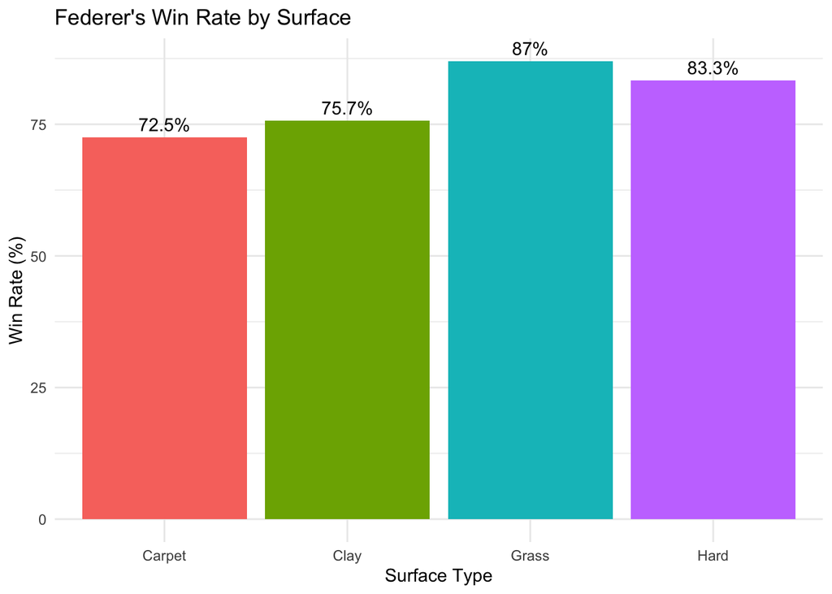

```r
federer_matches <- matches %>%
  filter(grepl("Roger Federer", winner_name) | grepl("Roger Federer", loser_name)) %>%
  mutate(federer_won = (winner_name == "Roger Federer"))

surface_data <- federer_matches %>%
  group_by(surface) %>%
  summarise(WinRate = mean(federer_won) * 100, .groups = 'drop')

ggplot(surface_data, aes(x = surface, y = WinRate, fill = surface)) +
  geom_col(show.legend = FALSE) +
  geom_text(aes(label = paste0(round(WinRate, 1), "%")), vjust = -0.5) +
  labs(
    title = "Federer's Win Rate by Surface",
    x = "Surface Type",
    y = "Win Rate (%)"
  ) +
  theme_minimal()
```

Federer’s strongest surface is Grass, where he has the highest win rate, followed by Hard courts. His win rate is slightly lower on Clay, which aligns with known career performance patterns.

## Win Rate by Tournament Level

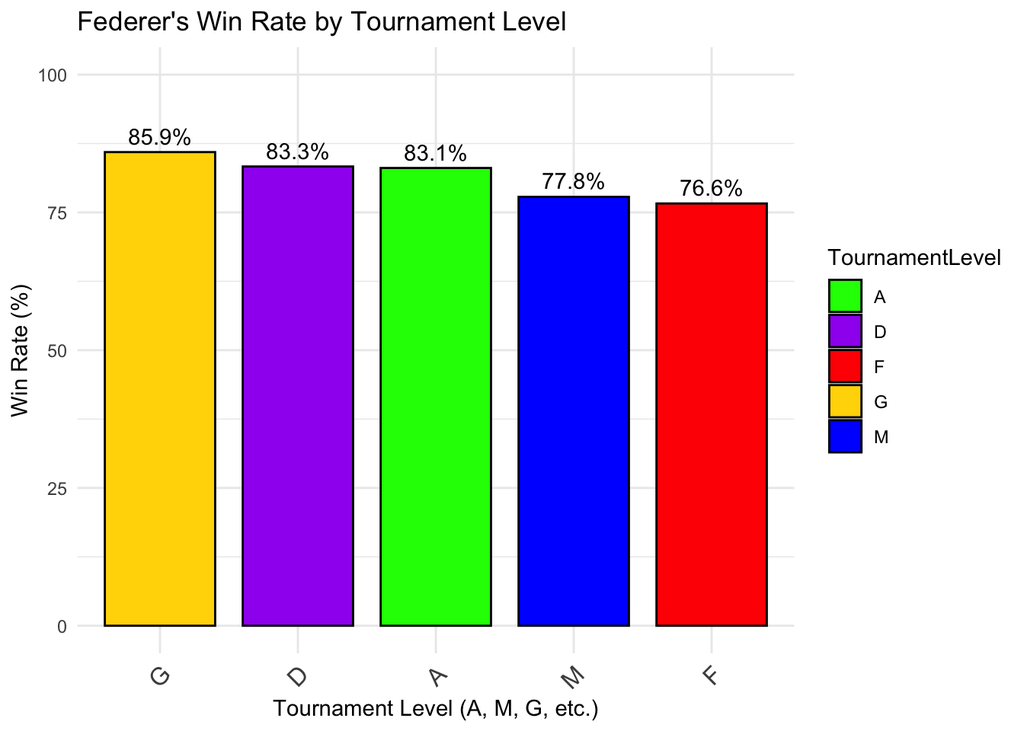

```r
tournament_stats <- federer_matches %>%
  group_by(TournamentLevel = tourney_level) %>%
  summarise(Wins = sum(winner_name == "Roger Federer"),
            Matches = n(),
            WinRate = Wins / Matches * 100, .groups = 'drop')

ggplot(tournament_stats, aes(x = reorder(TournamentLevel, -WinRate), y = WinRate, fill = TournamentLevel)) +
  geom_bar(stat = "identity", color = "black", width = 0.8) +
  geom_text(aes(label = paste0(round(WinRate, 1), "%")), vjust = -0.5) +
  scale_fill_manual(values = c("F" = "red", "M" = "blue", "A" = "green", "D" = "purple", "G" = "gold")) +
  labs(
    title = "Federer's Win Rate by Tournament Level",
    x = "Tournament Level (A, M, G, etc.)",
    y = "Win Rate (%)"
  ) +
  theme_minimal() +
  theme(axis.text.x = element_text(angle = 45, hjust = 1, size = 12)) +
  ylim(0, 100)
```

Federer performs consistently well in Grand Slam (G) and ATP 500 (A) tournaments, showing a high level of performance under pressure. Win rate dips slightly at the Masters 1000 (M) level, possibly due to stronger competition.

## Win Percentage and Loser’s Rank

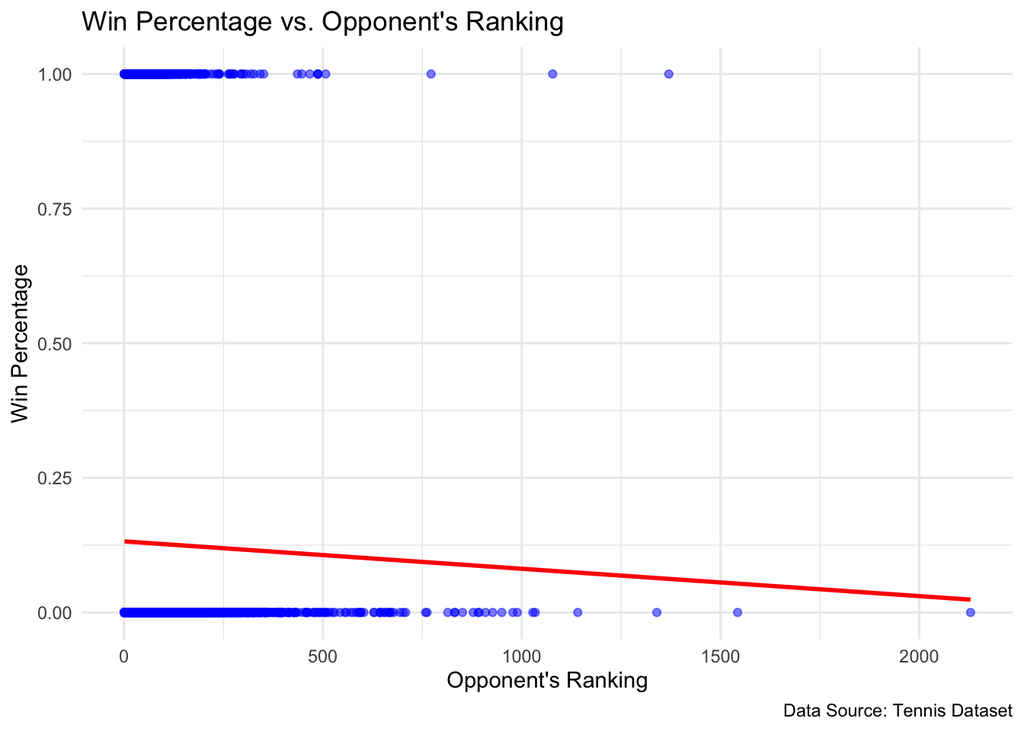

```r
matches <- matches %>%
  mutate(win_percentage = ifelse(winner_name == "Roger Federer", 1, 0))

ggplot(matches, aes(x = loser_rank, y = win_percentage)) +
  geom_point(alpha = 0.5, color = "blue") +  # Add scatter points
  geom_smooth(method = "lm", se = FALSE, color = "red") +  # Add regression line
  labs(title = "Win Percentage vs. Opponent's Ranking",
       x = "Opponent's Ranking",
       y = "Win Percentage",
       caption = "Data Source: Tennis Dataset") +
  theme_minimal()
```

## Correlation Analysis

```r
player_name <- "Rafael Nadal"

df <- matches %>%
  mutate(win_percentage = as.numeric(winner_name == player_name))

correlation <- cor(df$win_percentage, df$loser_rank, use = "complete.obs")

print(paste("Correlation between win percentage and opponent's ranking:", round(correlation, 5)))
```

```
## [1] "Correlation between win percentage and opponent's ranking: 0.00296"
```

```r
if (correlation > 0) {
  print("There is a positive correlation between win percentage and opponent's ranking.")
  print("This suggests that as the opponent's ranking increases, the player's win percentage also tends to increase.")
} else if (correlation < 0) {
  print("There is a negative correlation between win percentage and opponent's ranking.")
  print("This suggests that as the opponent's ranking increases, the player's win percentage tends to decrease.")
} else {
  print("There is no linear correlation between win percentage and opponent's ranking.")
}
```

[output not shown]

## Win Rate by Aces

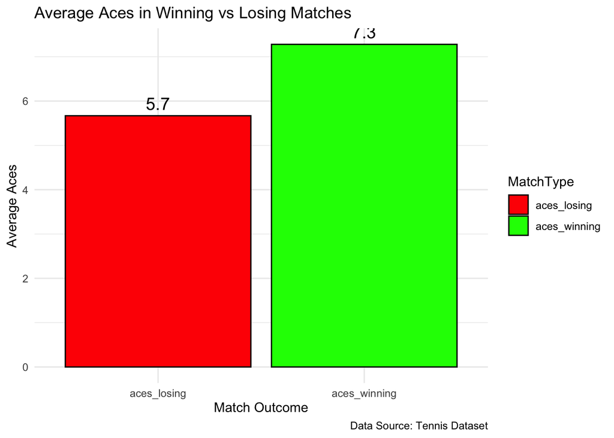

```r
aces_summary <- matches %>%
  summarise(aces_winning = mean(w_ace, na.rm = TRUE),
            aces_losing = mean(l_ace, na.rm = TRUE)) %>%
  pivot_longer(cols = c(aces_winning, aces_losing), names_to = "MatchType", values_to = "Aces")

ggplot(aces_summary, aes(x = MatchType, y = Aces, fill = MatchType)) +
  geom_bar(stat = "identity", color = "black") +
  geom_text(aes(label = round(Aces, 1)), vjust = -0.5, size = 5) +
  scale_fill_manual(values = c("aces_winning" = "green", "aces_losing" = "red")) +
  labs(title = "Average Aces in Winning vs Losing Matches",
       x = "Match Outcome",
       y = "Average Aces",
       caption = "Data Source: Tennis Dataset") +
  theme_minimal()
```

## T-test

```r
aces_winning <- matches %>%
  filter(!is.na(w_ace)) %>%
  pull(w_ace)

aces_losing <- matches %>%
  filter(!is.na(l_ace)) %>%
  pull(l_ace)

t_test_result <- t.test(aces_winning, aces_losing, var.equal = FALSE)

print(paste("T-statistic:", round(t_test_result$statistic, 5)))
```

```
## [1] "T-statistic: 19.27055"
```

```r
print(paste("P-value:", round(t_test_result$p.value, 5)))
```

```
## [1] "P-value: 0"
```

```r
if (t_test_result$p.value < 0.05) {
  print("There is a statistically significant difference in the average number of aces between winning and losing matches.")
} else {
  print("There is no statistically significant difference in the average number of aces between winning and losing matches.")
}
```

```
## [1] "There is a statistically significant difference in the average number of aces between winning and losing matches."
```

## Mutate

```r
library(dplyr)

matches <- matches %>%
  mutate(win_percentage = (winner_rank / (winner_rank + loser_rank)) * 100)
```

```r
matches <- matches %>%
  mutate(match_duration_category = case_when(
    minutes < 90 ~ "Short",
    minutes >= 90 & minutes <= 180 ~ "Medium",
    minutes > 180 ~ "Long",
    TRUE ~ "Unknown"
  ))
```

```r
matches <- matches %>%
  mutate(federer_favorite_surface = ifelse(surface == "Grass", "Yes", "No"))
```

```r
top_rivals <- c("Rafael Nadal", "Novak Djokovic", "Andy Murray")

matches <- matches %>%
  mutate(against_top_rival = ifelse(loser_name %in% top_rivals | winner_name %in% top_rivals, "Yes", "No"))
```

# Using mutate(), I added four new columns to the dataset:

*win_percentage* – Measures Federer’s ranking dominance in matches.

*match_duration_category* – Classifies matches as “Short”, “Medium”, or “Long” based on duration.

*federer_favorite_surface* – Identifies if a match was played on his preferred surface (Grass) based in the Win Rate by Surface graph.